# 24_biclustering

### [Biclustering](https://scikit-learn.org/stable/modules/biclustering.html)

- Simulaneously cluster the rows & columns of a matrix into "biclusters". Each defines a *submatrix* with some desired properties.
- Common bicluster definitions include:
  - constant values
  - unusually high/low values
  - low-variance submatrices
  - correlated rows/columns

```python
# given matrix (10,10)
# example bicluster w/ 3 rows, 2 cols
import numpy as np
data = np.arange(100).reshape(10, 10)
rows = np.array([0, 2, 3])[:, np.newaxis]
columns = np.array([1, 2])
data[rows, columns]
```

```
array([[ 1,  2],
       [21, 22],
       [31, 32]])
```

### Spectral Co-Clustering

- Finds biclusters with values *higher than those in corresponding other rows & columns*.
- Each row & column belongs to only one bicluster.
- Arranging the rows & columns create *contiguous partitions* reveals the high values along the diagonal.
- Algorithm treats input data as *a bipartite graph* (rows & cols represent two sets of vertices; each entry is *an edge between a row & column*. It approximates a *[normalized cut](http://www.sci.utah.edu/~gerig/CS7960-S2010/handouts/Normalized%20Graph%20cuts.pdf)* of the graph to find subgraphs.

### [Example](https://scikit-learn.org/stable/auto_examples/bicluster/plot_spectral_coclustering.html#sphx-glr-auto-examples-bicluster-plot-spectral-coclustering-py)

- uses `make_biclusters` to build a matrix of small values, then implant large-valued biclusters.
- The rows & columns are shuffled & passed to *Spectral CoClustering* algorithm.
- Rearranging the shuffled matrix should reveal the contiguous biclusters.

```python
import numpy as np
from matplotlib import pyplot as plt
from sklearn.datasets import make_biclusters
from sklearn.cluster import SpectralCoclustering as SC
from sklearn.metrics import consensus_score as CS
```

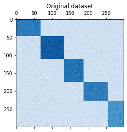

```python
data, rows, columns = make_biclusters(
    shape=(300, 300), n_clusters=5, noise=5,
    shuffle=False, random_state=0)

plt.matshow(data, cmap=plt.cm.Blues)
plt.title("Original dataset")
```

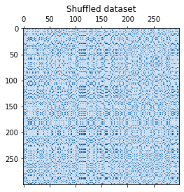

```python
rng = np.random.RandomState(0)
row_idx = rng.permutation(data.shape[0])
col_idx = rng.permutation(data.shape[1])
data = data[row_idx][:, col_idx]

plt.matshow(data, cmap=plt.cm.Blues)
plt.title("Shuffled dataset")
```

```
consensus score: 1.000
```

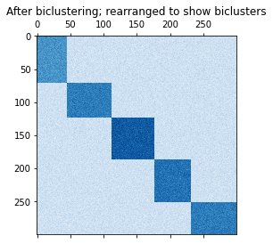

```python
model = SC(n_clusters=5, random_state=0)
model.fit(data)
score = CS(model.biclusters_,
           (rows[:,    row_idx],
            columns[:, col_idx]))

print("consensus score: {:.3f}".format(score))

fit_data =     data[   np.argsort(model.row_labels_   )]
fit_data = fit_data[:, np.argsort(model.column_labels_)]

plt.matshow(fit_data, cmap=plt.cm.Blues)
plt.title("After biclustering; rearranged to show biclusters")
```

### Spectral BiClustering

- Assumes input data has a *hidden checkerboard structure*.
- Partitions the rows & columns so that a corresponding blockwise-constant checkerboard matrix is a good approximation of the original.

### [Example Spectral Biclustering](https://scikit-learn.org/stable/auto_examples/bicluster/plot_spectral_biclustering.html#sphx-glr-auto-examples-bicluster-plot-spectral-biclustering-py)

- Data is generated using `make_checkerboard`, then shuffled and passed to the Biclustering algorithm. The rows & columns are then rearranged to show the discovered biclusters.

```python
import numpy as np
from matplotlib import pyplot as plt
from sklearn.datasets import make_checkerboard
from sklearn.cluster import SpectralBiclustering as SB
from sklearn.metrics import consensus_score as CS
```

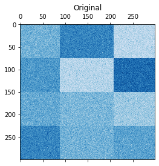

```python
n_clusters = (4, 3)
data, rows, columns = make_checkerboard(
    shape=(300, 300), n_clusters=n_clusters, noise=10,
    shuffle=False, random_state=0)

plt.matshow(data, cmap=plt.cm.Blues)
plt.title("Original")
```

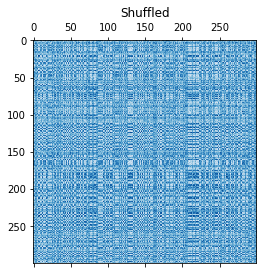

```python
rng = np.random.RandomState(0)
row_idx = rng.permutation(data.shape[0])
col_idx = rng.permutation(data.shape[1])
data = data[row_idx][:, col_idx]

plt.matshow(data, cmap=plt.cm.Blues)
plt.title("Shuffled")
```

```
consensus score: 1.0
```

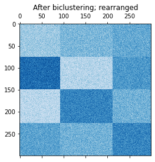

```python
model = SB(n_clusters=n_clusters, method='log', random_state=0)
model.fit(data)
score = CS(model.biclusters_,
           (rows[   :, row_idx],
            columns[:, col_idx]))

print("consensus score: {:.1f}".format(score))

fit_data =     data[   np.argsort(model.row_labels_)]
fit_data = fit_data[:, np.argsort(model.column_labels_)]

plt.matshow(fit_data, cmap=plt.cm.Blues)
plt.title("After biclustering; rearranged")
```

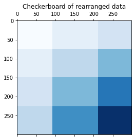

```python
plt.matshow(np.outer(np.sort(model.row_labels_) + 1,
                     np.sort(model.column_labels_) + 1),
            cmap=plt.cm.Blues)
plt.title("Checkerboard of rearranged data")
```

### Metrics / Evaluation

- Currently in Scikit-Learn: no way to use self-guided measures such as cluster stability. Must rely on external measures using true data.
- True is usually unavailable. Biclustering with artificial data may be useful given the true data is known.
- Use the *Jaccard index* to *compare individual biclusters*: $J(A, B) = \frac{|A \cap B|}{|A| + |B| - |A \cap B|}$ where $A$ & $B$ are biclusters and $|A \cap B|$ is the #elements in the intersection.
  - Jaccard index = 0: no overlap
  - Jaccard index = 1: identical biclusters
- Use the *[consensus score](https://scikit-learn.org/stable/modules/generated/sklearn.metrics.consensus_score.html#sklearn.metrics.consensus_score)* to compare *two sets of biclusters*.
  - Consensus score = 0: all bicluster pairs are totally dissimilar.
  - Consensus score = 1: both sets are identical.